# wanting_35507071_TaskD

Wanting Echo Zhao

2026-05-27

# Question 1

## **Mind map**

- Find differences between faculties and sexes: extract these columns and convert to factors.
- Extract them to individual datasets for further testing.
- Compare differences between groups using t-test and ANOVA.

```r
# Set working directory to where the data files are located (run this chunk if in VSCode not RStudio project)
setwd("/Users/ez_us/Documents/5145/Assignment4/TaskD")
```

```r
# Load data and convert relevant columns to factors
independent_data <- read.csv("TaskD_Dataset/forum_ind_train.csv", stringsAsFactors = FALSE)
independent_data$demographic_sex <- factor(independent_data$demographic_sex)
independent_data$unit_faculty <- factor(independent_data$unit_faculty)

# Preview the data
head(independent_data$demographic_sex)
```

```
## [1] F M M M F M
## Levels: F M X
```

```r
head(independent_data$unit_faculty)
```

```
## [1] Faculty of Art Des & Architecture Faculty of Art Des & Architecture
## [3] Faculty of Art Des & Architecture Faculty of Art Des & Architecture
## [5] Faculty of Art Des & Architecture Faculty of Art Des & Architecture
## 10 Levels: Faculty of Art Des & Architecture ... Faculty of Science
```

```r
dplyr::count(independent_data, demographic_sex)
```

```
##   demographic_sex    n
## 1               F 1540
## 2               M 1043
## 3               X    2
## 4            <NA>    5
```

```r
# Identify LIWC variables (all except ID and categoricals)
liwc_vars <- setdiff(names(independent_data), c("Unique_ID", "unit_faculty", "demographic_sex"))
```

### Compare by Sex

```r
# Remove rows with ambiguous or missing sex values
sex_data <- independent_data[independent_data$demographic_sex %in% c("F", "M"), ]
sex_data$demographic_sex <- droplevels(sex_data$demographic_sex)

# Function to run t-test for each LIWC variable by sex
sex_ttest_results <- lapply(liwc_vars, function(v) {
  tt <- t.test(sex_data[[v]] ~ sex_data$demographic_sex)
  data.frame(
    variable = v,
    mean_F = tt$estimate[1],
    mean_M = tt$estimate[2],
    diff = tt$estimate[1] - tt$estimate[2],
    p_value = tt$p.value
  )
})
sex_results <- do.call(rbind, sex_ttest_results) # combine two data frames
sex_results$p_adj <- p.adjust(sex_results$p_value, method = "BH") # Adjust for multiple comparisons to control the false discovery rate or family-wise error rate. Benjamini-Hochberg, controls FDR
sex_results <- sex_results[order(sex_results$p_adj), ]
head(sex_results, 10)
```

```
##                    variable      mean_F       mean_M       diff      p_value
## mean in group F7        Dic  80.4855909  77.94405561  2.5415353 1.396408e-05
## mean in group F36    family   0.1852208   0.06485139  0.1203694 4.756860e-05
## mean in group F35    social   8.9888961   7.83867689  1.1502192 9.892704e-05
## mean in group F87    Exclam   1.3851623   0.43369128  0.9514711 2.275302e-04
## mean in group F27    number   2.5308766   3.46762224 -0.9367456 4.274295e-04
## mean in group F51       bio   1.3518701   1.00059444  0.3512757 8.316909e-04
## mean in group F2      Clout  60.0347468  56.65326942  3.3814773 1.279430e-03
## mean in group F8  function.  46.7163701  45.16945350  1.5469166 1.540299e-03
## mean in group F45   certain   1.3326948   1.08024928  0.2524455 3.190315e-03
## mean in group F          WC 122.0798701 105.53595398 16.5439162 6.020217e-03
##                         p_adj
## mean in group F7  0.001298659
## mean in group F36 0.002211940
## mean in group F35 0.003066738
## mean in group F87 0.005290078
## mean in group F27 0.007950190
## mean in group F51 0.012891208
## mean in group F2  0.016998148
## mean in group F8  0.017905977
## mean in group F45 0.032966593
## mean in group F   0.040906195
```

### Compare by Faculty

```r
# Remove rows with missing faculty
faculty_data <- independent_data[!is.na(independent_data$unit_faculty), ]
faculty_data$unit_faculty <- droplevels(faculty_data$unit_faculty)

# Function to run ANOVA for each LIWC variable by faculty
faculty_anova_results <- lapply(liwc_vars, function(v) {
  fit <- aov(faculty_data[[v]] ~ faculty_data$unit_faculty)
  p <- summary(fit)[[1]][["Pr(>F)"]][1]
  data.frame(variable = v, p_value = p)
})
fac_results <- do.call(rbind, faculty_anova_results)
fac_results$p_adj <- p.adjust(fac_results$p_value, method = "BH")
fac_results <- fac_results[order(fac_results$p_adj), ]
head(fac_results, 10)
```

```
##    variable       p_value         p_adj
## 73    money 4.777871e-152 4.443420e-150
## 54   health 6.690237e-122 3.110960e-120
## 52      bio  3.352807e-90  1.039370e-88
## 70     work  1.612131e-63  3.748204e-62
## 8       Dic  2.125717e-33  3.953834e-32
## 7    Sixltr  3.182575e-33  4.932992e-32
## 28   number  1.476799e-32  1.962033e-31
## 36   social  1.967062e-32  2.286709e-31
## 1        WC  3.328604e-26  3.439558e-25
## 16     they  2.161596e-24  1.827531e-23
```

### Group Means for Standout Variable

```r
# Example: mean of 'money' variable by faculty
tapply(faculty_data$money, faculty_data$unit_faculty, mean)
```

```
##   Faculty of Art Des & Architecture                     Faculty of Arts
##                           0.8529041                           0.8989895
##     Faculty of Business & Economics                Faculty of Education
##                           4.3795185                           0.3338516
##              Faculty of Engineering   Faculty of Information Technology
##                           0.5569286                           0.3256679
##                      Faculty of Law Faculty of Med Nursing & Health Sci
##                           1.0695370                           0.3118537
## Faculty of Pharmacy & Pharm Science                  Faculty of Science
##                           0.2048485                           0.1339320
```

### Plots

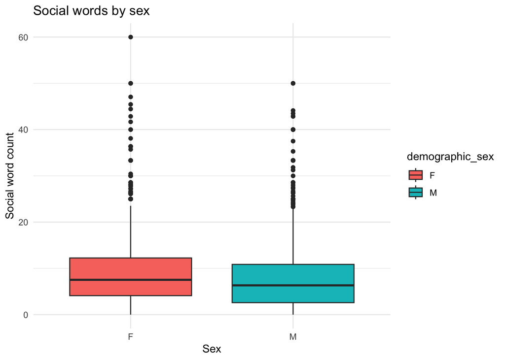

```r
library(ggplot2)
# Boxplot: Social words by sex
ggplot(sex_data, aes(demographic_sex, social, fill = demographic_sex)) +
  geom_boxplot() +
  labs(title = "Social words by sex", x = "Sex", y = "Social word count") +
  theme_minimal()
```

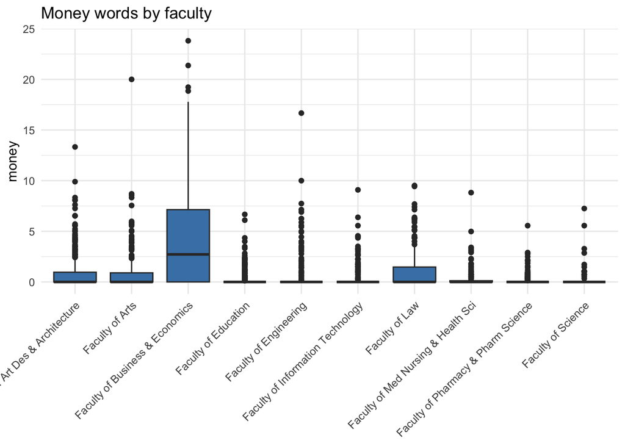

```r
# Boxplot: Money words by faculty
ggplot(faculty_data, aes(unit_faculty, money)) +
  geom_boxplot(fill = "steelblue") +
  labs(title = "Money words by faculty", x = NULL, y = "money") +
  theme_minimal() + theme(axis.text.x = element_text(angle = 45, hjust = 1))
```

**Sex:** 15 of 93 variables differ significantly (adjusted p < 0.05). The biggest gaps: women’s posts score higher on social (8.99 vs 7.84), family (0.19 vs 0.06), Exclam (1.39 vs 0.43), Clout, and are longer overall (WC 122 vs 106 words); men score higher on number (3.47 vs 2.53). These line up with well-documented LIWC gender patterns — more affiliative/social language from women, more numeric language from men.

Differences between faculties are much larger and more pervasive than differences between sexes, and the strongest faculty differences are content/topic words that reflect what each discipline talks about.

# Question 2

The ind and dep files are joined on Unique_ID to form the modelling table, and a single cleaning function is applied to both train and validation so they are treated identically. I evaluate three classifiers covered in the unit — a decision tree, logistic regression and naive Bayes — each trained on all independent variables. Performance is measured with accuracy, precision, recall and F1, treating Content-relevant as the positive class so that F1 is consistent with the metric used for Q4 and Q5.

```r
# Load required libraries
library(rpart)
library(e1071)
library(MLmetrics)

# Helper function: join independent and dependent data by Unique_ID
read_join <- function(ind_file, dep_file) {
  x <- read.csv(ind_file, stringsAsFactors = FALSE)
  y <- read.csv(dep_file, stringsAsFactors = FALSE)
  merge(x, y, by = "Unique_ID")
}

# Helper function: clean dataset (remove duplicates, handle NAs, set factors)
clean <- function(df) {
  df <- df[!duplicated(df$Unique_ID), ]  # Remove duplicate IDs
  num <- setdiff(names(df), c("Unique_ID","unit_faculty","demographic_sex","label"))
  df <- df[rowSums(is.na(df[num])) < length(num), ]  # Remove all-NA rows
  df <- df[!is.na(df$label), ]  # Remove rows with missing label
  df$unit_faculty <- ifelse(is.na(df$unit_faculty), "Unknown", df$unit_faculty)
  df$demographic_sex <- ifelse(df$demographic_sex %in% c("F","M"), df$demographic_sex, "Unknown")
  df$unit_faculty <- factor(df$unit_faculty)
  df$demographic_sex <- factor(df$demographic_sex)
  df$label <- factor(df$label, levels = c("Content-irrelevant","Content-relevant"))
  df
}

# Prepare training and validation sets
train <- clean(read_join("TaskD_Dataset/forum_ind_train.csv", "TaskD_Dataset/forum_dep_train.csv"))
val <- clean(read_join("TaskD_Dataset/forum_ind_validation.csv", "TaskD_Dataset/forum_dep_validation.csv"))
val$unit_faculty <- factor(val$unit_faculty, levels = levels(train$unit_faculty))
val$demographic_sex <- factor(val$demographic_sex, levels = levels(train$demographic_sex))

# Define predictors and formula
predictors <- setdiff(names(train), c("Unique_ID", "label"))
form <- as.formula(paste("label ~", paste(predictors, collapse = " + ")))

# Helper function: evaluate model metrics
eval_metrics <- function(actual, predicted, positive = "Content-relevant") {
  data.frame(
    accuracy  = Accuracy(y_pred = predicted, y_true = actual),
    precision = Precision(y_true = actual, y_pred = predicted, positive = positive),
    recall = Recall(y_true = actual, y_pred = predicted, positive = positive),
    f1 = F1_Score(y_true = actual, y_pred = predicted, positive = positive)
  )
}

# Fit and predict: Decision Tree
fit_tree <- rpart(form, data = train, method = "class")
pred_tree <- predict(fit_tree, val, type = "class")

# Fit and predict: Logistic Regression
fit_glm <- glm(form, data = train, family = binomial)
pred_glm <- ifelse(predict(fit_glm, val, type = "response") > 0.5, "Content-relevant", "Content-irrelevant")

# Fit and predict: Naive Bayes
fit_nb <- naiveBayes(form, data = train)
pred_nb <- predict(fit_nb, val)

# Combine results for easy comparison
results <- rbind(
  cbind(model = "Decision tree", eval_metrics(val$label, pred_tree)),
  cbind(model = "Logistic regression", eval_metrics(val$label, pred_glm)),
  cbind(model = "Naive Bayes", eval_metrics(val$label, pred_nb))
)
results
```

```
##                 model  accuracy precision    recall        f1
## 1       Decision tree 0.8630631 0.8971722 0.9064935 0.9018088
## 2 Logistic regression 0.8810811 0.8880779 0.9480519 0.9170854
## 3         Naive Bayes 0.8090090 0.8163265 0.9350649 0.8716707
```

**Logistic regression** performs best on the validation set *(F1 = 0.917, accuracy = 0.881)*, ahead of the **decision tree** *(F1 = 0.902)* and **naive Bayes** *(F1 = 0.872)*. Logistic regression is chosen as Model 1. **Naive Bayes** has the weakest precision, likely due to its strong independence assumption being violated by correlated LIWC variables.

> Note: Fitting logistic regression on all 95 predictors triggers a “fitted probabilities numerically 0 or 1” warning, indicating quasi-separation and a risk of overfitting. This motivates the variable-selection and alternative-model experiments in Q4.

# Question 3

```r
library(rpart)
library(ggplot2)

# Method 1: Decision-tree variable importance
fit_tree <- rpart(form, data = train, method = "class")
imp <- sort(fit_tree$variable.importance, decreasing = TRUE)
head(imp, 15) # Show top 15 important variables
```

```
##          WC         WPS       cause     compare       power         adj
##  408.638714  247.797265  213.886009  199.974974  177.949758  172.006446
##           i       ppron       Clout     pronoun   Authentic affiliation
##  135.259027   46.347070   24.365380   21.691697   19.860817   14.169445
##        conj     AllPunc      Period
##   10.616691   10.218565    9.820439
```

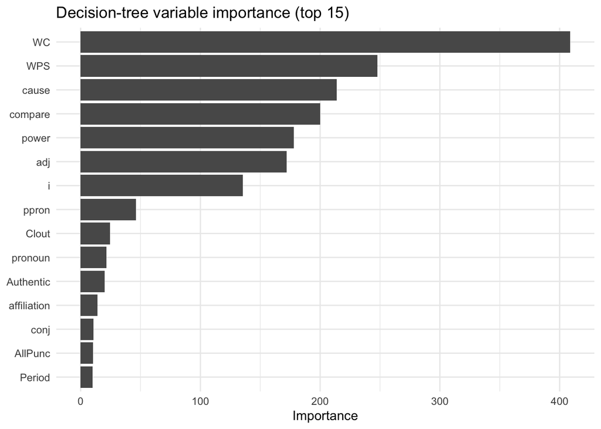

```r
# Plot top 15 important variables
imp_df <- data.frame(variable = names(imp), importance = as.numeric(imp))[1:15, ]
imp_df$variable <- factor(imp_df$variable, levels = rev(imp_df$variable))
ggplot(imp_df, aes(variable, importance)) +
  geom_col() +
  coord_flip() +
  labs(title = "Decision-tree variable importance (top 15)", x = NULL, y = "Importance") +
  theme_minimal()
```

```r
# Method 2: Univariate t-test for each LIWC variable by label
liwc_vars <- setdiff(predictors, c("unit_faculty", "demographic_sex"))

# Apply for-loop for clarity: run t-tests, then build the data frame
t_test_results <- lapply(liwc_vars, function(v) {
  tt <- t.test(train[[v]] ~ train$label)
  data.frame(variable = v,
             mean_irrel = tt$estimate[1],
             mean_rel = tt$estimate[2],
             t_stat = unname(tt$statistic),
             p_value = tt$p.value)
})
uni <- do.call(rbind, t_test_results)
uni$p_adj <- p.adjust(uni$p_value, method = "BH")
uni <- uni[order(abs(uni$t_stat), decreasing = TRUE), ]
head(uni, 15)
```

```
##                                        variable mean_irrel    mean_rel
## mean in group Content-irrelevant             WC 36.3326203 160.2009685
## mean in group Content-irrelevant10        ppron  9.6484385   4.3666768
## mean in group Content-irrelevant5           WPS 12.6573476  22.5884140
## mean in group Content-irrelevant1      Analytic 54.5842246  79.3370339
## mean in group Content-irrelevant11            i  5.7613048   1.7116949
## mean in group Content-irrelevant9       pronoun 14.2488449   8.8300424
## mean in group Content-irrelevant6        Sixltr 18.5701070  26.0753692
## mean in group Content-irrelevant18         prep 10.0503850  13.6423245
## mean in group Content-irrelevant42        cause  1.4466738   3.0883051
## mean in group Content-irrelevant17      article  5.3663957   7.8849395
## mean in group Content-irrelevant57  affiliation  4.6146524   2.0607506
## mean in group Content-irrelevant63 focuspresent 13.1721711   9.1150242
## mean in group Content-irrelevant15         they  0.2122995   0.8063015
## mean in group Content-irrelevant72        money  0.3252193   1.3023245
## mean in group Content-irrelevant23         verb 16.8915294  12.6935412
##                                       t_stat       p_value         p_adj
## mean in group Content-irrelevant   -27.20340 1.891502e-138 1.759097e-136
## mean in group Content-irrelevant10  20.92911  2.248226e-83  6.969500e-82
## mean in group Content-irrelevant5  -20.82156  4.546200e-89  2.113983e-87
## mean in group Content-irrelevant1  -20.66984  7.331501e-83  1.704574e-81
## mean in group Content-irrelevant11  20.60563  1.744226e-80  3.244259e-79
## mean in group Content-irrelevant9   17.21877  7.434214e-60  1.152303e-58
## mean in group Content-irrelevant6  -16.30207  6.399095e-55  8.501655e-54
## mean in group Content-irrelevant18 -14.91951  1.078119e-46  1.114056e-45
## mean in group Content-irrelevant42 -14.82103  4.647752e-47  5.403012e-46
## mean in group Content-irrelevant17 -13.30423  2.505839e-38  2.330430e-37
## mean in group Content-irrelevant57  13.12147  9.802368e-37  8.287456e-36
## mean in group Content-irrelevant63  12.87095  1.409435e-35  1.008288e-34
## mean in group Content-irrelevant15 -12.71133  6.052196e-36  4.690452e-35
## mean in group Content-irrelevant72 -12.10064  8.714563e-33  5.788959e-32
## mean in group Content-irrelevant23  12.04949  1.143817e-31  7.091668e-31
```

```r
# Compare overlap between top variables from both methods
intersect(names(head(imp, 15)), head(uni$variable, 15))
```

```
## [1] "WC"          "WPS"         "cause"       "i"           "ppron"
## [6] "pronoun"     "affiliation"
```

```r
# Categorical predictors: chi-square tests
chisq.test(table(train$demographic_sex, train$label))   # Sex vs label
```

```
##
##  Pearson's Chi-squared test
##
## data:  table(train$demographic_sex, train$label)
## X-squared = 3.0287, df = 2, p-value = 0.22
```

```r
chisq.test(table(train$unit_faculty, train$label))   # Faculty vs label
```

```
##
##  Pearson's Chi-squared test
##
## data:  table(train$unit_faculty, train$label)
## X-squared = 141.77, df = 9, p-value < 2.2e-16
```

```r
# Proportion tables for interpretation
prop.table(table(train$demographic_sex, train$label), 1) # Relevance rate by sex
```

```
##
##           Content-irrelevant Content-relevant
##   F                0.3551948        0.6448052
##   M                0.3720038        0.6279962
##   Unknown          0.0000000        1.0000000
```

```r
prop.table(table(train$unit_faculty, train$label), 1)  # Relevance rate by faculty
```

```
##
##                                       Content-irrelevant Content-relevant
##   Faculty of Art Des & Architecture            0.2931507        0.7068493
##   Faculty of Arts                              0.2264808        0.7735192
##   Faculty of Business & Economics              0.2037037        0.7962963
##   Faculty of Education                         0.3992933        0.6007067
##   Faculty of Engineering                       0.5357143        0.4642857
##   Faculty of Information Technology            0.4187726        0.5812274
##   Faculty of Law                               0.5138889        0.4861111
##   Faculty of Med Nursing & Health Sci          0.2585366        0.7414634
##   Faculty of Pharmacy & Pharm Science          0.3535354        0.6464646
##   Faculty of Science                           0.4611650        0.5388350
```

Two independent methods — decision-tree importance and a univariate t-test of each variable by class — agree on a core set of important variables (WC, WPS, cause, i, ppron, pronoun, affiliation). Word count is by far the strongest signal: content-relevant posts are much longer (160 vs 36 words) and more elaborated (WPS, Sixltr, Analytic).

Conversely, content-irrelevant posts use more first-person and personal pronouns and affiliation words, reflecting short social or logistical messages. In short, relevance is driven by post length and a formal-reasoning-versus-personal-chat contrast. This informs Q4, where I test whether a model built on this important subset can outperform Model 1.

The two categorical variables were tested with chi-square, the appropriate test for categorical predictors. Sex is not associated with the label (χ² = 3.03, p = 0.22; relevance rate ≈ 64% for famele and 62.8% for male), whereas faculty is strongly associated (χ² = 141.8, p < 0.001), with content-relevant rates ranging from about 46% (Engineering, Law) to 80% (Business & Economics, Arts).

Thus the important predictors are **post length and analytic-versus-personal language (numeric LIWC variables) together with the unit’s faculty**; the author’s sex carries no predictive value.

Because here is juding “relevant/irrelevant”, utilizing “class” method for `rpart()`(desision tree) functiont to predicts a discrete category or class label.

# Question 4

**Methods to be used:**

- Decision tree (`rpart`)
- kNN
- Logistic regression (raw and log-transformed)

```r
# Q4: Model comparison and improvement
library(rpart)
library(e1071)
library(class)
library(MLmetrics)

# 1. Isolate variable types
num_vars <- setdiff(names(train), c("Unique_ID", "unit_faculty","demographic_sex", "label"))
all_vars <- setdiff(names(train), c("Unique_ID", "label"))

# 2. Select top 20 most important variables by t-statistic magnitude
get_t_stat <- function(variable_name) {
  test_result <- t.test(train[[variable_name]] ~ train$label)
  abs(unname(test_result$statistic))
}
tt_abs <- sapply(num_vars, get_t_stat)
important <- names(sort(tt_abs, decreasing = TRUE))[1:20]

# 3. Log-transform LIWC variables to address skewness
trainL <- train
valL   <- val
trainL[num_vars] <- log1p(train[num_vars])
valL[num_vars]   <- log1p(val[num_vars])

# 4. Initialize model leaderboard
cand <- list()

# Model 1: Baseline Logistic Regression (Raw Data)
m_base    <- suppressWarnings(glm(reformulate(all_vars, "label"), data = train, family = binomial))
pred_base <- ifelse(predict(m_base, val, type = "response") > 0.5, "Content-relevant", "Content-irrelevant")
cand[["logistic all (Model 1)"]] <- F1_Score(y_true = val$label, y_pred = pred_base, positive = "Content-relevant")

# Model 2: Improved Logistic Regression (Log-Transformed Data)
m_log    <- glm(reformulate(all_vars, "label"), data = trainL, family = binomial)
pred_log <- ifelse(predict(m_log, valL, type = "response") > 0.5, "Content-relevant", "Content-irrelevant")
cand[["logistic log1p all (improved)"]] <- F1_Score(y_true = val$label, y_pred = pred_log, positive = "Content-relevant")

# Model 3: Decision Tree
tree_model <- rpart(reformulate(all_vars, "label"), data = train, method = "class")
pred_tree  <- predict(tree_model, val, type = "class")
cand[["decision tree all"]] <- F1_Score(y_true = val$label, y_pred = pred_tree, positive = "Content-relevant")

# Model 4: kNN using only the 20 'important' features
sc <- scale(train[num_vars])
va_sc <- scale(val[num_vars], center = attr(sc, "scaled:center"), scale = attr(sc, "scaled:scale"))
pred_knn <- knn(train = sc[, important], test = va_sc[, important], cl = train$label, k = 9)
cand[["kNN important k=9"]] <- F1_Score(y_true = val$label, y_pred = pred_knn, positive = "Content-relevant")

# 5. Print out the leaderboard
data.frame(model = names(cand), F1 = round(unlist(cand), 4))
```

```
##                                                       model     F1
## logistic all (Model 1)               logistic all (Model 1) 0.9171
## logistic log1p all (improved) logistic log1p all (improved) 0.9227
## decision tree all                         decision tree all 0.9018
## kNN important k=9                         kNN important k=9 0.9158
```

```r
# 6. Final analysis of the winner (logistic regression on log-transformed data)
F1_Score(y_true = val$label, y_pred = pred_log, positive = "Content-relevant")  # F1 validation score
```

```
## [1] 0.9226869
```

```r
table(predicted = pred_log, actual = val$label) # Confusion matrix
```

```
##                     actual
## predicted            Content-irrelevant Content-relevant
##   Content-irrelevant                130               21
##   Content-relevant                   40              364
```

# Question 5

```r
# Q5: Predict on test set and prepare submission

# Final model: logistic regression on log-transformed variables
num_vars <- setdiff(names(train), c("Unique_ID", "unit_faculty","demographic_sex","label"))
all_vars <- setdiff(names(train), c("Unique_ID", "label"))

trainL <- train
trainL[num_vars] <- log1p(train[num_vars])
final_model <- glm(reformulate(all_vars, "label"), data = trainL, family = binomial)

# Read the test files (do NOT drop rows: every row needs a label)
ind_test <- read.csv("TaskD_Dataset/forum_ind_test.csv", stringsAsFactors = FALSE)
dep_test <- read.csv("TaskD_Dataset/forum_dep_test.csv", stringsAsFactors = FALSE)

# Clean up categoricals and apply same factor levels as training
ind_test$unit_faculty <- ifelse(is.na(ind_test$unit_faculty), "Unknown", ind_test$unit_faculty)
ind_test$demographic_sex <- ifelse(ind_test$demographic_sex %in% c("F","M"), ind_test$demographic_sex, "Unknown")
ind_test$unit_faculty <- factor(ind_test$unit_faculty,    levels = levels(train$unit_faculty))
ind_test$demographic_sex <- factor(ind_test$demographic_sex, levels = levels(train$demographic_sex))
ind_test[num_vars] <- log1p(ind_test[num_vars])  # Apply same transformation

# Predict and fill dep_test's label column in its original row order
prob <- predict(final_model, ind_test, type = "response")
pred <- ifelse(prob > 0.5, "Content-relevant", "Content-irrelevant")
pred_by_id <- data.frame(Unique_ID = ind_test$Unique_ID, pred = pred)
dep_test$label <- pred_by_id$pred[match(dep_test$Unique_ID, pred_by_id$Unique_ID)]

# Handle any test row with all-NA features by assigning the majority class
dep_test$label[is.na(dep_test$label)] <- names(sort(table(train$label), decreasing = TRUE))[1]

# Write submission: same 2 columns, 556 rows, unquoted
write.csv(dep_test, "Zhao_35507071_forum_label_test.csv", row.names = FALSE, quote = FALSE)
```